# Penanganan Ketidakstasioneran - Tugas Praktikum 6

Bryant Indervil Deadora G1401231062

# Import Packages

```r
library(rio)
library(ggplot2)
library(tsibble)
library(tseries)
library(MASS)
library(tidyverse)
```

# Praproses Data

```r
df <- import("https://raw.githubusercontent.com/bryantddr/mpdw/refs/heads/main/Pertemuan%202/Bitcoin.csv")
df <- df %>%
  mutate(
    Price = gsub(pattern = ",", replacement = "", x = Price),
    Price = as.numeric(Price),
    Price = Price/1000)
df <- df[379:504,2]
df
```

```
##   [1]  27.9412  30.2996  27.8139  29.2341  28.8571  26.7775  27.1162  26.8575
##   [9]  27.0720  25.8440  26.5150  30.5336  30.5868  30.2888  30.2914  29.7889
##  [17]  29.3535  29.0681  29.4282  26.0994  26.0171  25.8697  25.9011  26.5620
##  [25]  26.5792  26.9627  27.9611  26.8528  29.9129  34.0826  35.0658  37.1505
##  [33]  36.5686  37.7870  39.4584  43.7184  42.2717  43.7104  42.1367  43.9679
##  [41]  42.8513  41.6954  42.1209  43.0057  47.7582  51.6460  51.5716  61.9945
##  [49]  68.3665  65.3142  64.0378  69.6115  68.8906  63.8499  64.9611  63.4568
##  [57]  63.8883  60.8266  66.9175  69.2844  67.7608  69.3101  66.2230  64.2610
##  [65]  60.9734  58.2592  59.2098  67.1485  67.8431  60.6967  60.9317  59.4831
##  [73]  64.1593  58.9786  54.1565  59.9954  63.3481  65.8665  62.0614  63.2051
##  [81]  68.3720  67.0868  69.3258  76.7003  90.5391  97.6990  96.4057  99.8370
##  [89] 101.4177  97.2533  95.2845  98.2199  94.6120  94.5361 104.7429 100.6480
##  [97]  96.4479  97.5734  96.5561  86.0716  86.2219  84.3413  83.8405  82.6457
## [105]  83.5521  85.2927  85.0681  94.6314  95.8858 104.7980 103.1126 107.7630
## [113] 104.5980 105.5642 105.4215 102.1132 107.3044 108.2047 117.4195 117.8484
## [121] 117.9176 112.5477 116.4716 117.4134 115.4333 110.4039
```

```r
ts.df <- ts(df)
ts.df
```

```
## Time Series:
## Start = 1
## End = 126
## Frequency = 1
##   [1]  27.9412  30.2996  27.8139  29.2341  28.8571  26.7775  27.1162  26.8575
##   [9]  27.0720  25.8440  26.5150  30.5336  30.5868  30.2888  30.2914  29.7889
##  [17]  29.3535  29.0681  29.4282  26.0994  26.0171  25.8697  25.9011  26.5620
##  [25]  26.5792  26.9627  27.9611  26.8528  29.9129  34.0826  35.0658  37.1505
##  [33]  36.5686  37.7870  39.4584  43.7184  42.2717  43.7104  42.1367  43.9679
##  [41]  42.8513  41.6954  42.1209  43.0057  47.7582  51.6460  51.5716  61.9945
##  [49]  68.3665  65.3142  64.0378  69.6115  68.8906  63.8499  64.9611  63.4568
##  [57]  63.8883  60.8266  66.9175  69.2844  67.7608  69.3101  66.2230  64.2610
##  [65]  60.9734  58.2592  59.2098  67.1485  67.8431  60.6967  60.9317  59.4831
##  [73]  64.1593  58.9786  54.1565  59.9954  63.3481  65.8665  62.0614  63.2051
##  [81]  68.3720  67.0868  69.3258  76.7003  90.5391  97.6990  96.4057  99.8370
##  [89] 101.4177  97.2533  95.2845  98.2199  94.6120  94.5361 104.7429 100.6480
##  [97]  96.4479  97.5734  96.5561  86.0716  86.2219  84.3413  83.8405  82.6457
## [105]  83.5521  85.2927  85.0681  94.6314  95.8858 104.7980 103.1126 107.7630
## [113] 104.5980 105.5642 105.4215 102.1132 107.3044 108.2047 117.4195 117.8484
## [121] 117.9176 112.5477 116.4716 117.4134 115.4333 110.4039
```

# Ekplorasi Data

## Plot Time Series

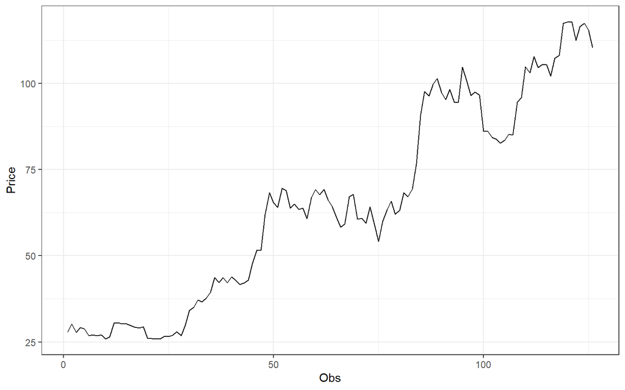

```r
plot_df <- ts.df |> as_tsibble() |>
  ggplot(aes(x = index, y = value)) + geom_line() + theme_bw() +
  xlab("Obs") + ylab("Price")
plot_df
```

```r
mean(ts.df)
```

```
## [1] 64.75688
```

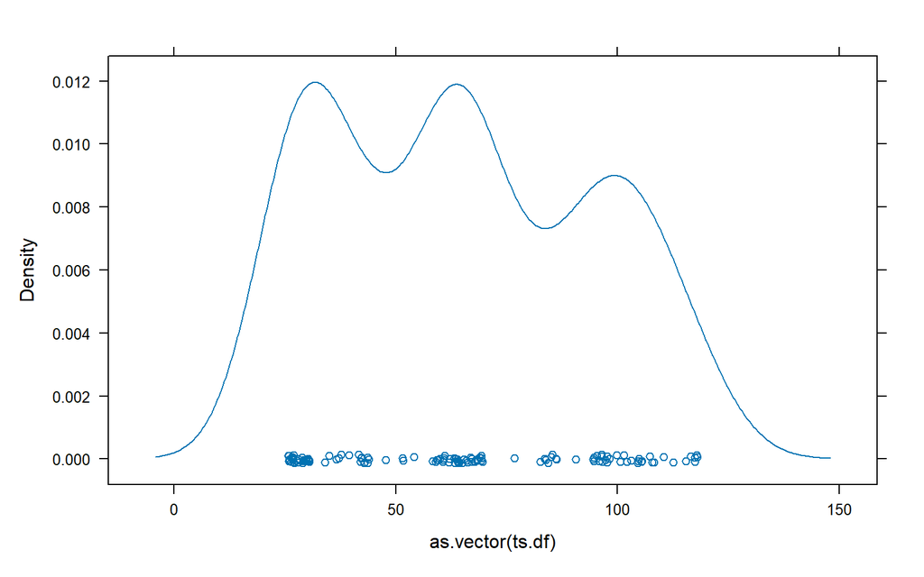

```r
lattice::densityplot(as.vector(ts.df))
```

Berdasarkan plot, terlihat data tidak stasioner dalam rataan maupun ragam, ditandai data tidak menyebar di sekitar nilai tengahnya, cenderung adanya tren.

Dalam data ekonomi termasuk Bitcoin, hal ini hampir pasti terjadi. Oleh karena itu, akan dilakukan pengananan lebih lanjut.

## Plot ACF

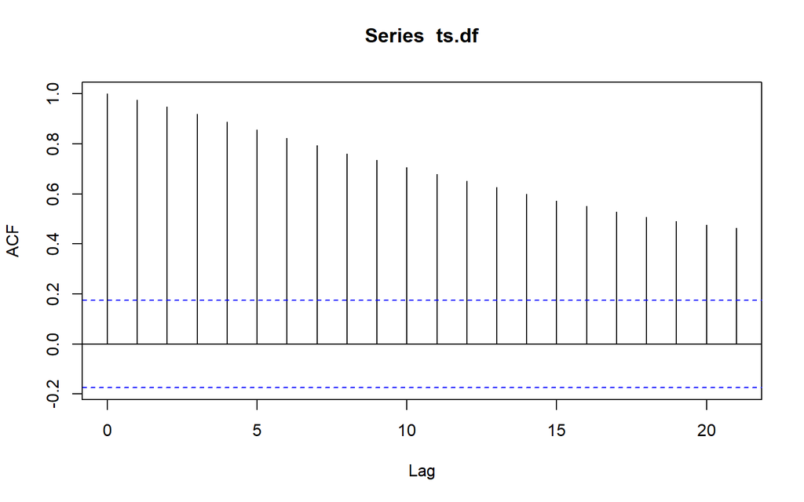

```r
acf(ts.df)
```

Berdasarkan plot ACF, terdapat autokorelasi positif dan tidak stationer.

## Uji PP

```r
pp.test(ts.df)
```

```
##
##  Phillips-Perron Unit Root Test
##
## data:  ts.df
## Dickey-Fuller Z(alpha) = -17.356, Truncation lag parameter = 4, p-value
## = 0.1131
## alternative hypothesis: stationary
```

$H_0$ : Data tidak stasioner dalam rataan $H_1$ : Data stasioner dalam rataan

## Uji Box-Cox

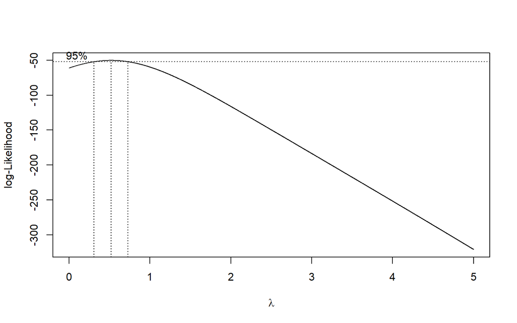

```r
index <- seq(1:126)

# Uji Box-Cox
bc <- boxcox(
  ts.df  ~ index,
  lambda = seq(0, 5, by = 0.001)
)
```

```r
lambda <- bc$x[which.max(bc$y)]
lambda
```

```
## [1] 0.518
```

```r
# Selang kepercayaan 95% untuk lambda
ci_lambda <- bc$x[bc$y > max(bc$y) - 0.5 * qchisq(0.95, 1)]

# Batas bawah dan batas atas
ci_lower <- min(ci_lambda)
ci_upper <- max(ci_lambda)

c(Batas_Bawah = ci_lower, Batas_Atas = ci_upper)
```

```
## Batas_Bawah  Batas_Atas
##       0.306       0.729
```

Hasil uji Box-Cox menunjukkan bahwa nilai $\lambda$ optimum adalah 0.518 dengan interval kepercayaan 95% (0.306,0.729). Selang tidak mengandung 1, maka data tidak stasioner dalam ragam.

# Penanganan Ketidakstasioneran

## Hanya Differencing

### Differencing

```r
ts.df_diff1 <- diff(ts.df, differences = 1)
```

### Plot Time Series

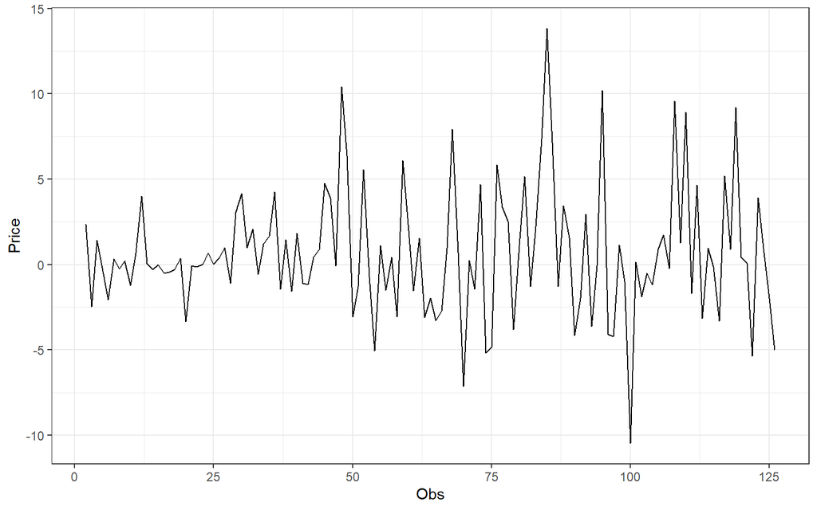

```r
plot_df_diff1 <- ts.df_diff1 |> as_tsibble() |>
  ggplot(aes(x = index, y = value)) + geom_line() + theme_bw() +
  xlab("Obs") + ylab("Price")
plot_df_diff1
```

Berdasarkan plot, data terlihat menyebar pada rataan yang berarti stasioner pada rataan. Namun, sekilas terlihat belum stasioner pada ragam.

### Plot ACF

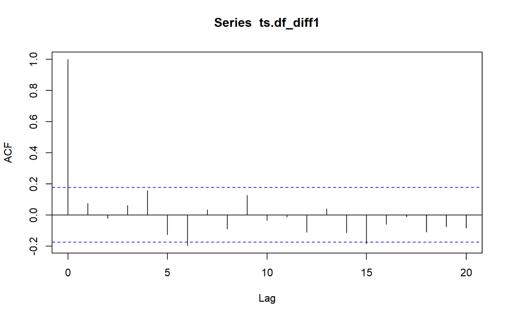

```r
acf(ts.df_diff1)
```

Berdasarkan Plot ACF, terlihat sudah stasioner dalam rataan. Hasil ini sama dengan time series plot.

### Uji PP

```r
pp.test(ts.df_diff1)
```

```
##
##  Phillips-Perron Unit Root Test
##
## data:  ts.df_diff1
## Dickey-Fuller Z(alpha) = -119.44, Truncation lag parameter = 4, p-value
## = 0.01
## alternative hypothesis: stationary
```

Berdasarkan uji PP, *p-value* = 0.01 < 0.05 = $\alpha$, tolak H0. Data sudah stasioner pada rataan, sesuai dengan hasil dari *time series plot* dan plot ACF

### Uji Box-Cox

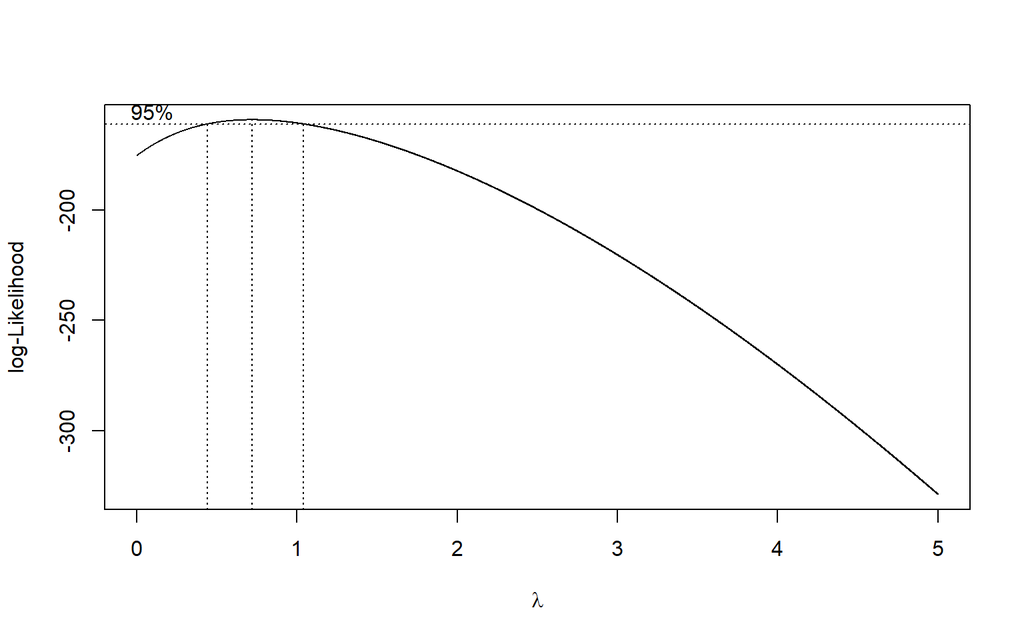

```r
index <- seq(1:125)

# Uji Box-Cox
bc <- boxcox(
  ts.df_diff1 - min(ts.df_diff1) + 1  ~ index,
  lambda = seq(0, 5, by = 0.001)
)
```

```r
# Selang kepercayaan 95% untuk lambda
ci_lambda <- bc$x[bc$y > max(bc$y) - 0.5 * qchisq(0.95, 1)]

# Batas bawah dan batas atas
ci_lower <- min(ci_lambda)
ci_upper <- max(ci_lambda)

c(Batas_Bawah = ci_lower, Batas_Atas = ci_upper)
```

```
## Batas_Bawah  Batas_Atas
##       0.440       1.038
```

Berdasarkan Uji Box-Cox, interval kepercayaan 95% $\lambda$ sebesar (0.440,1.038). Dalam selang ini terdapat nilai $\lambda$ = 1, namun selang tersebut terlalu mendekati nilai 1 yaitu 1.038. Bisa terjadi kekeliruan, oleh karena itu akan dilakukan transformasi Box-Cox terlebih dahulu sebelum *Differencing*.

## Transformasi Box-Cox -> *Differencing*

### Transformasi Box-Cox

Berdasarkan Uji Box-Cox pada eksplorasi data didapatkan nilai $\lambda$ optimum sebesar 0.518, maka data akan dipangkatkan $\frac{1}{2}$

```r
ts.df_bc <- ts.df^0.5
```

### Differencing

```r
ts.df_bc_diff1 <- diff(ts.df_bc, differences = 1)
```

### Plot Time Series

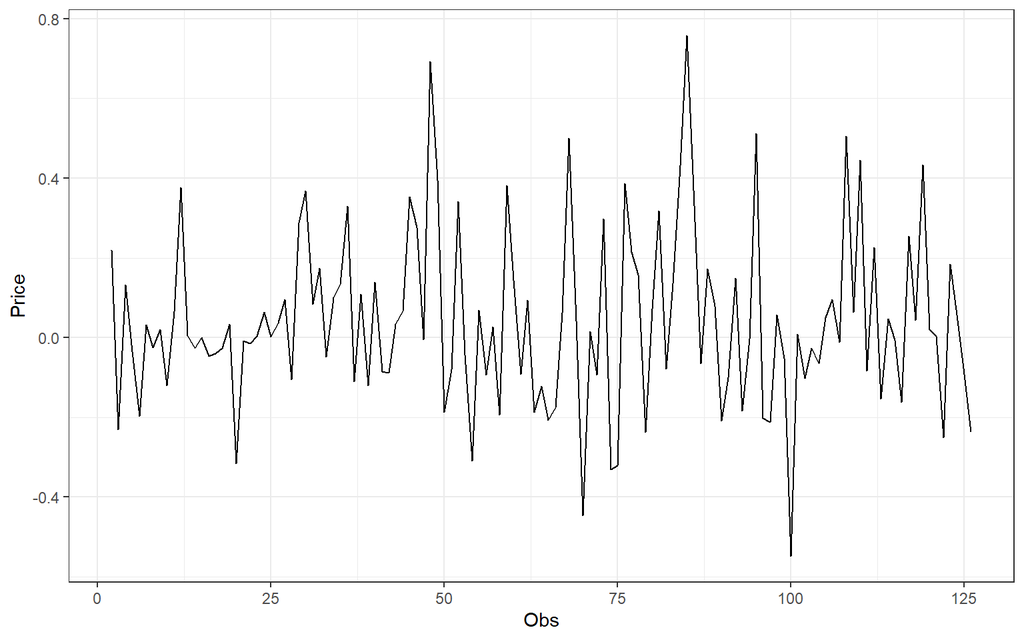

```r
plot_df_bc_diff1 <- ts.df_bc_diff1 |> as_tsibble() |>
  ggplot(aes(x = index, y = value)) + geom_line() + theme_bw() +
  xlab("Obs") + ylab("Price")
plot_df_bc_diff1
```

Berdasarkan plot, data terlihat menyebar pada rataan yang berarti stasioner pada rataan dan sekilas stasioner pada ragam.